# Risk Factor Analysis

## Outcome Variable

**Outcome Variable:** ever_stunted

## Predictor Variables

**Intervention Variable:** born_wasted

**Adjustment Set:**

- arm
- sex
- W_mage
- meducyrs
- feducyrs
- hhwealth_quart
- vagbrth
- W_nrooms
- month
- brthmon
- W_parity
- impfloor
- impsan
- delta_W_mage
- delta_meducyrs
- delta_feducyrs
- delta_hhwealth_quart
- delta_vagbrth
- delta_W_nrooms
- delta_month
- delta_brthmon
- delta_W_parity
- delta_impfloor
- delta_impsan

## Stratifying Variables

The analysis was stratified on these variable(s):

- agecat
- studyid
- country

## Data Summary

| agecat | studyid | country | born_wasted | ever_stunted | n_cell | n |
| --- | --- | --- | --- | --- | --- | --- |
| 0-3 months | ki0047075b-MAL-ED | BANGLADESH | 0 | 0 | 179 | 244 |
| 0-3 months | ki0047075b-MAL-ED | BANGLADESH | 0 | 1 | 25 | 244 |
| 0-3 months | ki0047075b-MAL-ED | BANGLADESH | 1 | 0 | 37 | 244 |
| 0-3 months | ki0047075b-MAL-ED | BANGLADESH | 1 | 1 | 3 | 244 |
| 0-3 months | ki0047075b-MAL-ED | BRAZIL | 0 | 0 | 164 | 183 |
| 0-3 months | ki0047075b-MAL-ED | BRAZIL | 0 | 1 | 13 | 183 |
| 0-3 months | ki0047075b-MAL-ED | BRAZIL | 1 | 0 | 6 | 183 |
| 0-3 months | ki0047075b-MAL-ED | BRAZIL | 1 | 1 | 0 | 183 |
| 0-3 months | ki0047075b-MAL-ED | INDIA | 0 | 0 | 151 | 204 |
| 0-3 months | ki0047075b-MAL-ED | INDIA | 0 | 1 | 19 | 204 |
| 0-3 months | ki0047075b-MAL-ED | INDIA | 1 | 0 | 30 | 204 |
| 0-3 months | ki0047075b-MAL-ED | INDIA | 1 | 1 | 4 | 204 |
| 0-3 months | ki0047075b-MAL-ED | NEPAL | 0 | 0 | 142 | 168 |
| 0-3 months | ki0047075b-MAL-ED | NEPAL | 0 | 1 | 6 | 168 |
| 0-3 months | ki0047075b-MAL-ED | NEPAL | 1 | 0 | 19 | 168 |
| 0-3 months | ki0047075b-MAL-ED | NEPAL | 1 | 1 | 1 | 168 |
| 0-3 months | ki0047075b-MAL-ED | PERU | 0 | 0 | 216 | 282 |
| 0-3 months | ki0047075b-MAL-ED | PERU | 0 | 1 | 60 | 282 |
| 0-3 months | ki0047075b-MAL-ED | PERU | 1 | 0 | 5 | 282 |
| 0-3 months | ki0047075b-MAL-ED | PERU | 1 | 1 | 1 | 282 |
| 0-3 months | ki0047075b-MAL-ED | SOUTH AFRICA | 0 | 0 | 201 | 258 |
| 0-3 months | ki0047075b-MAL-ED | SOUTH AFRICA | 0 | 1 | 39 | 258 |
| 0-3 months | ki0047075b-MAL-ED | SOUTH AFRICA | 1 | 0 | 17 | 258 |
| 0-3 months | ki0047075b-MAL-ED | SOUTH AFRICA | 1 | 1 | 1 | 258 |
| 0-3 months | ki0047075b-MAL-ED | TANZANIA, UNITED REPUBLIC OF | 0 | 0 | 125 | 145 |
| 0-3 months | ki0047075b-MAL-ED | TANZANIA, UNITED REPUBLIC OF | 0 | 1 | 18 | 145 |
| 0-3 months | ki0047075b-MAL-ED | TANZANIA, UNITED REPUBLIC OF | 1 | 0 | 2 | 145 |
| 0-3 months | ki0047075b-MAL-ED | TANZANIA, UNITED REPUBLIC OF | 1 | 1 | 0 | 145 |
| 0-3 months | ki1000108-CMC-V-BCS-2002 | INDIA | 0 | 0 | 56 | 84 |
| 0-3 months | ki1000108-CMC-V-BCS-2002 | INDIA | 0 | 1 | 18 | 84 |

[output cut: 410 more lines]

The following strata were considered:

- agecat: 0-3 months, studyid: ki0047075b-MAL-ED, country: BANGLADESH
- agecat: 0-3 months, studyid: ki0047075b-MAL-ED, country: BRAZIL
- agecat: 0-3 months, studyid: ki0047075b-MAL-ED, country: INDIA
- agecat: 0-3 months, studyid: ki0047075b-MAL-ED, country: NEPAL
- agecat: 0-3 months, studyid: ki0047075b-MAL-ED, country: PERU
- agecat: 0-3 months, studyid: ki0047075b-MAL-ED, country: SOUTH AFRICA
- agecat: 0-3 months, studyid: ki0047075b-MAL-ED, country: TANZANIA, UNITED REPUBLIC OF
- agecat: 0-3 months, studyid: ki1000108-CMC-V-BCS-2002, country: INDIA
- agecat: 0-3 months, studyid: ki1000108-IRC, country: INDIA
- agecat: 0-3 months, studyid: ki1000109-EE, country: PAKISTAN
- agecat: 0-3 months, studyid: ki1000109-ResPak, country: PAKISTAN
- agecat: 0-3 months, studyid: ki1000304b-SAS-CompFeed, country: INDIA
- agecat: 0-3 months, studyid: ki1017093-NIH-Birth, country: BANGLADESH
- agecat: 0-3 months, studyid: ki1017093b-PROVIDE, country: BANGLADESH
- agecat: 0-3 months, studyid: ki1017093c-NIH-Crypto, country: BANGLADESH
- agecat: 0-3 months, studyid: ki1101329-Keneba, country: GAMBIA
- agecat: 0-3 months, studyid: ki1114097-CMIN, country: BANGLADESH
- agecat: 0-3 months, studyid: ki1114097-CMIN, country: BRAZIL
- agecat: 0-3 months, studyid: ki1114097-CMIN, country: GUINEA-BISSAU
- agecat: 0-3 months, studyid: ki1114097-CMIN, country: PERU
- agecat: 0-3 months, studyid: ki1114097-CONTENT, country: PERU
- agecat: 0-3 months, studyid: ki1119695-PROBIT, country: BELARUS
- agecat: 0-3 months, studyid: ki1126311-ZVITAMBO, country: ZIMBABWE
- agecat: 0-3 months, studyid: ki1135781-COHORTS, country: GUATEMALA
- agecat: 0-3 months, studyid: ki1135781-COHORTS, country: INDIA
- agecat: 0-3 months, studyid: ki1135781-COHORTS, country: PHILIPPINES
- agecat: 0-3 months, studyid: kiGH5241-JiVitA-3, country: BANGLADESH
- agecat: 0-3 months, studyid: kiGH5241-JiVitA-4, country: BANGLADESH
- agecat: 12-24 months, studyid: ki0047075b-MAL-ED, country: BANGLADESH
- agecat: 12-24 months, studyid: ki0047075b-MAL-ED, country: BRAZIL
- agecat: 12-24 months, studyid: ki0047075b-MAL-ED, country: INDIA
- agecat: 12-24 months, studyid: ki0047075b-MAL-ED, country: NEPAL
- agecat: 12-24 months, studyid: ki0047075b-MAL-ED, country: PERU
- agecat: 12-24 months, studyid: ki0047075b-MAL-ED, country: SOUTH AFRICA
- agecat: 12-24 months, studyid: ki0047075b-MAL-ED, country: TANZANIA, UNITED REPUBLIC OF
- agecat: 12-24 months, studyid: ki1000108-CMC-V-BCS-2002, country: INDIA
- agecat: 12-24 months, studyid: ki1000108-IRC, country: INDIA
- agecat: 12-24 months, studyid: ki1000109-EE, country: PAKISTAN
- agecat: 12-24 months, studyid: ki1000109-ResPak, country: PAKISTAN
- agecat: 12-24 months, studyid: ki1000304b-SAS-CompFeed, country: INDIA
- agecat: 12-24 months, studyid: ki1017093-NIH-Birth, country: BANGLADESH
- agecat: 12-24 months, studyid: ki1017093b-PROVIDE, country: BANGLADESH
- agecat: 12-24 months, studyid: ki1017093c-NIH-Crypto, country: BANGLADESH
- agecat: 12-24 months, studyid: ki1101329-Keneba, country: GAMBIA
- agecat: 12-24 months, studyid: ki1114097-CMIN, country: BANGLADESH
- agecat: 12-24 months, studyid: ki1114097-CMIN, country: BRAZIL
- agecat: 12-24 months, studyid: ki1114097-CMIN, country: GUINEA-BISSAU
- agecat: 12-24 months, studyid: ki1114097-CMIN, country: PERU
- agecat: 12-24 months, studyid: ki1114097-CONTENT, country: PERU
- agecat: 12-24 months, studyid: ki1119695-PROBIT, country: BELARUS
- agecat: 12-24 months, studyid: ki1126311-ZVITAMBO, country: ZIMBABWE
- agecat: 12-24 months, studyid: ki1135781-COHORTS, country: GUATEMALA
- agecat: 12-24 months, studyid: ki1135781-COHORTS, country: PHILIPPINES
- agecat: 12-24 months, studyid: kiGH5241-JiVitA-3, country: BANGLADESH
- agecat: 12-24 months, studyid: kiGH5241-JiVitA-4, country: BANGLADESH
- agecat: 3-6 months, studyid: ki0047075b-MAL-ED, country: BANGLADESH
- agecat: 3-6 months, studyid: ki0047075b-MAL-ED, country: BRAZIL
- agecat: 3-6 months, studyid: ki0047075b-MAL-ED, country: INDIA
- agecat: 3-6 months, studyid: ki0047075b-MAL-ED, country: NEPAL
- agecat: 3-6 months, studyid: ki0047075b-MAL-ED, country: PERU
- agecat: 3-6 months, studyid: ki0047075b-MAL-ED, country: SOUTH AFRICA
- agecat: 3-6 months, studyid: ki0047075b-MAL-ED, country: TANZANIA, UNITED REPUBLIC OF
- agecat: 3-6 months, studyid: ki1000108-CMC-V-BCS-2002, country: INDIA
- agecat: 3-6 months, studyid: ki1000108-IRC, country: INDIA
- agecat: 3-6 months, studyid: ki1000109-EE, country: PAKISTAN
- agecat: 3-6 months, studyid: ki1000109-ResPak, country: PAKISTAN
- agecat: 3-6 months, studyid: ki1000304b-SAS-CompFeed, country: INDIA
- agecat: 3-6 months, studyid: ki1017093-NIH-Birth, country: BANGLADESH
- agecat: 3-6 months, studyid: ki1017093b-PROVIDE, country: BANGLADESH
- agecat: 3-6 months, studyid: ki1017093c-NIH-Crypto, country: BANGLADESH
- agecat: 3-6 months, studyid: ki1101329-Keneba, country: GAMBIA
- agecat: 3-6 months, studyid: ki1114097-CMIN, country: BANGLADESH
- agecat: 3-6 months, studyid: ki1114097-CMIN, country: BRAZIL
- agecat: 3-6 months, studyid: ki1114097-CMIN, country: GUINEA-BISSAU
- agecat: 3-6 months, studyid: ki1114097-CMIN, country: PERU
- agecat: 3-6 months, studyid: ki1114097-CONTENT, country: PERU
- agecat: 3-6 months, studyid: ki1119695-PROBIT, country: BELARUS
- agecat: 3-6 months, studyid: ki1126311-ZVITAMBO, country: ZIMBABWE
- agecat: 3-6 months, studyid: ki1135781-COHORTS, country: GUATEMALA
- agecat: 3-6 months, studyid: ki1135781-COHORTS, country: PHILIPPINES
- agecat: 3-6 months, studyid: kiGH5241-JiVitA-3, country: BANGLADESH
- agecat: 3-6 months, studyid: kiGH5241-JiVitA-4, country: BANGLADESH
- agecat: 6-12 months, studyid: ki0047075b-MAL-ED, country: BANGLADESH
- agecat: 6-12 months, studyid: ki0047075b-MAL-ED, country: BRAZIL
- agecat: 6-12 months, studyid: ki0047075b-MAL-ED, country: INDIA
- agecat: 6-12 months, studyid: ki0047075b-MAL-ED, country: NEPAL
- agecat: 6-12 months, studyid: ki0047075b-MAL-ED, country: PERU
- agecat: 6-12 months, studyid: ki0047075b-MAL-ED, country: SOUTH AFRICA
- agecat: 6-12 months, studyid: ki0047075b-MAL-ED, country: TANZANIA, UNITED REPUBLIC OF
- agecat: 6-12 months, studyid: ki1000108-CMC-V-BCS-2002, country: INDIA
- agecat: 6-12 months, studyid: ki1000108-IRC, country: INDIA
- agecat: 6-12 months, studyid: ki1000109-EE, country: PAKISTAN
- agecat: 6-12 months, studyid: ki1000109-ResPak, country: PAKISTAN
- agecat: 6-12 months, studyid: ki1000304b-SAS-CompFeed, country: INDIA
- agecat: 6-12 months, studyid: ki1017093-NIH-Birth, country: BANGLADESH
- agecat: 6-12 months, studyid: ki1017093b-PROVIDE, country: BANGLADESH
- agecat: 6-12 months, studyid: ki1017093c-NIH-Crypto, country: BANGLADESH
- agecat: 6-12 months, studyid: ki1101329-Keneba, country: GAMBIA
- agecat: 6-12 months, studyid: ki1114097-CMIN, country: BANGLADESH
- agecat: 6-12 months, studyid: ki1114097-CMIN, country: BRAZIL
- agecat: 6-12 months, studyid: ki1114097-CMIN, country: GUINEA-BISSAU
- agecat: 6-12 months, studyid: ki1114097-CMIN, country: PERU
- agecat: 6-12 months, studyid: ki1114097-CONTENT, country: PERU
- agecat: 6-12 months, studyid: ki1119695-PROBIT, country: BELARUS
- agecat: 6-12 months, studyid: ki1126311-ZVITAMBO, country: ZIMBABWE
- agecat: 6-12 months, studyid: ki1135781-COHORTS, country: GUATEMALA
- agecat: 6-12 months, studyid: ki1135781-COHORTS, country: INDIA
- agecat: 6-12 months, studyid: ki1135781-COHORTS, country: PHILIPPINES
- agecat: 6-12 months, studyid: kiGH5241-JiVitA-3, country: BANGLADESH
- agecat: 6-12 months, studyid: kiGH5241-JiVitA-4, country: BANGLADESH

### Dropped Strata

Some strata were dropped due to rare outcomes:

- agecat: 0-3 months, studyid: ki0047075b-MAL-ED, country: BANGLADESH
- agecat: 0-3 months, studyid: ki0047075b-MAL-ED, country: BRAZIL
- agecat: 0-3 months, studyid: ki0047075b-MAL-ED, country: INDIA
- agecat: 0-3 months, studyid: ki0047075b-MAL-ED, country: NEPAL
- agecat: 0-3 months, studyid: ki0047075b-MAL-ED, country: PERU
- agecat: 0-3 months, studyid: ki0047075b-MAL-ED, country: SOUTH AFRICA
- agecat: 0-3 months, studyid: ki0047075b-MAL-ED, country: TANZANIA, UNITED REPUBLIC OF
- agecat: 0-3 months, studyid: ki1000108-CMC-V-BCS-2002, country: INDIA
- agecat: 0-3 months, studyid: ki1000109-ResPak, country: PAKISTAN
- agecat: 0-3 months, studyid: ki1114097-CMIN, country: BANGLADESH
- agecat: 0-3 months, studyid: ki1114097-CMIN, country: BRAZIL
- agecat: 0-3 months, studyid: ki1114097-CMIN, country: GUINEA-BISSAU
- agecat: 0-3 months, studyid: ki1114097-CMIN, country: PERU
- agecat: 0-3 months, studyid: ki1114097-CONTENT, country: PERU
- agecat: 0-3 months, studyid: kiGH5241-JiVitA-4, country: BANGLADESH
- agecat: 3-6 months, studyid: ki0047075b-MAL-ED, country: BANGLADESH
- agecat: 3-6 months, studyid: ki0047075b-MAL-ED, country: BRAZIL
- agecat: 3-6 months, studyid: ki0047075b-MAL-ED, country: INDIA
- agecat: 3-6 months, studyid: ki0047075b-MAL-ED, country: NEPAL
- agecat: 3-6 months, studyid: ki0047075b-MAL-ED, country: PERU
- agecat: 3-6 months, studyid: ki0047075b-MAL-ED, country: SOUTH AFRICA
- agecat: 3-6 months, studyid: ki0047075b-MAL-ED, country: TANZANIA, UNITED REPUBLIC OF
- agecat: 3-6 months, studyid: ki1000108-CMC-V-BCS-2002, country: INDIA
- agecat: 3-6 months, studyid: ki1000109-ResPak, country: PAKISTAN
- agecat: 3-6 months, studyid: ki1101329-Keneba, country: GAMBIA
- agecat: 3-6 months, studyid: ki1114097-CMIN, country: BANGLADESH
- agecat: 3-6 months, studyid: ki1114097-CMIN, country: BRAZIL
- agecat: 3-6 months, studyid: ki1114097-CMIN, country: GUINEA-BISSAU
- agecat: 3-6 months, studyid: ki1114097-CMIN, country: PERU
- agecat: 3-6 months, studyid: ki1114097-CONTENT, country: PERU
- agecat: 6-12 months, studyid: ki0047075b-MAL-ED, country: BRAZIL
- agecat: 6-12 months, studyid: ki0047075b-MAL-ED, country: INDIA
- agecat: 6-12 months, studyid: ki0047075b-MAL-ED, country: NEPAL
- agecat: 6-12 months, studyid: ki0047075b-MAL-ED, country: PERU
- agecat: 6-12 months, studyid: ki0047075b-MAL-ED, country: SOUTH AFRICA
- agecat: 6-12 months, studyid: ki0047075b-MAL-ED, country: TANZANIA, UNITED REPUBLIC OF
- agecat: 6-12 months, studyid: ki1000108-CMC-V-BCS-2002, country: INDIA
- agecat: 6-12 months, studyid: ki1000109-EE, country: PAKISTAN
- agecat: 6-12 months, studyid: ki1000109-ResPak, country: PAKISTAN
- agecat: 6-12 months, studyid: ki1101329-Keneba, country: GAMBIA
- agecat: 6-12 months, studyid: ki1114097-CMIN, country: BANGLADESH
- agecat: 6-12 months, studyid: ki1114097-CMIN, country: BRAZIL
- agecat: 6-12 months, studyid: ki1114097-CMIN, country: GUINEA-BISSAU
- agecat: 6-12 months, studyid: ki1114097-CMIN, country: PERU
- agecat: 6-12 months, studyid: ki1114097-CONTENT, country: PERU
- agecat: 12-24 months, studyid: ki0047075b-MAL-ED, country: BRAZIL
- agecat: 12-24 months, studyid: ki0047075b-MAL-ED, country: INDIA
- agecat: 12-24 months, studyid: ki0047075b-MAL-ED, country: PERU
- agecat: 12-24 months, studyid: ki0047075b-MAL-ED, country: SOUTH AFRICA
- agecat: 12-24 months, studyid: ki0047075b-MAL-ED, country: TANZANIA, UNITED REPUBLIC OF
- agecat: 12-24 months, studyid: ki1000108-CMC-V-BCS-2002, country: INDIA
- agecat: 12-24 months, studyid: ki1000109-EE, country: PAKISTAN
- agecat: 12-24 months, studyid: ki1000109-ResPak, country: PAKISTAN
- agecat: 12-24 months, studyid: ki1101329-Keneba, country: GAMBIA
- agecat: 12-24 months, studyid: ki1114097-CMIN, country: BANGLADESH
- agecat: 12-24 months, studyid: ki1114097-CMIN, country: BRAZIL
- agecat: 12-24 months, studyid: ki1114097-CMIN, country: GUINEA-BISSAU
- agecat: 12-24 months, studyid: ki1114097-CMIN, country: PERU
- agecat: 12-24 months, studyid: ki1114097-CONTENT, country: PERU

## Methods Detail

We’re interested in the causal parameters $E[Y_a]$ for all values of $a \in \mathcal{A}$. These parameters represent the mean outcome if, possibly contrary to fact, we intervened to set all units to have $A=a$. Under the randomization and positivity assumptions, these are identified by the statistical parameters $\psi_a=E_W[E_{Y|A,W}(Y|A=a,W)]$. In addition, we’re interested in the mean of $Y$, $E[Y]$ under no intervention (the observed mean). We will estimate these parameters by using SuperLearner to fit the relevant likelihood factors – $E_{Y|A,W}(Y|A=a,W)$ and $p(A=a|W)$, and then updating our likelihood fit using a joint TMLE.

For unadjusted analyses ($W=\{\}$), initial likelihoods were estimated using Lrnr_glm to estimate the simple $E(Y|A)$ and Lrnr_mean to estimate $p(A)$. For adjusted analyses, a small library containing Lrnr_glmnet, Lrnr_xgboost, and Lrnr_mean was used.

Having estimated these parameters, we will then use the delta method to estimate relative risks and attributable risks relative to a prespecified baseline level of $A$.

# Results Detail

## Results Plots

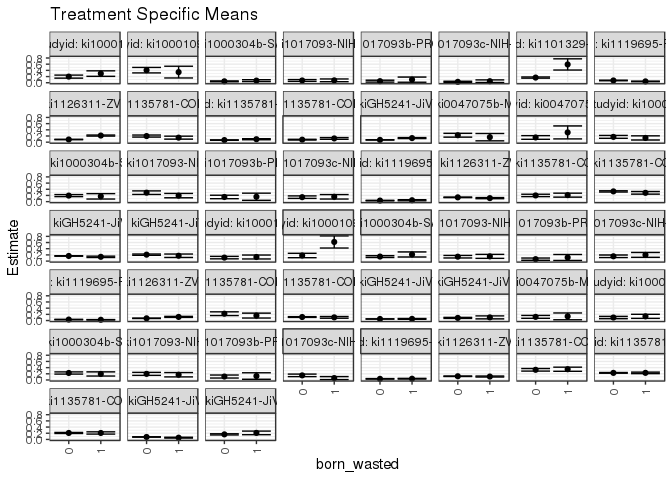

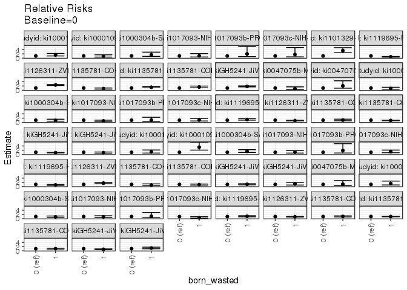

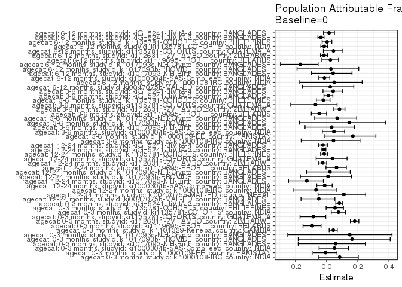

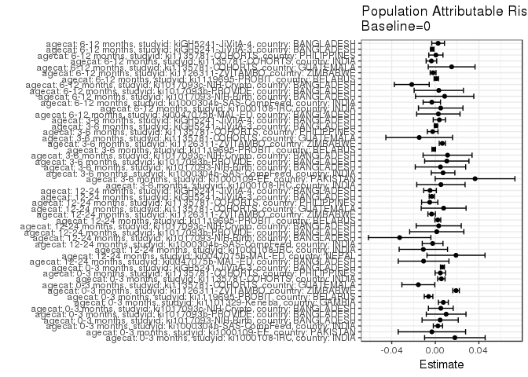

## Results Table

### Parameter: TSM

| agecat | studyid | country | intervention_level | baseline_level | estimate | ci_lower | ci_upper |
| --- | --- | --- | --- | --- | --- | --- | --- |
| 0-3 months | ki1000108-IRC | INDIA | 0 | NA | 0.1977675 | 0.1487749 | 0.2467600 |
| 0-3 months | ki1000108-IRC | INDIA | 1 | NA | 0.2959621 | 0.2071064 | 0.3848177 |
| 0-3 months | ki1000109-EE | PAKISTAN | 0 | NA | 0.4061105 | 0.3174185 | 0.4948026 |
| 0-3 months | ki1000109-EE | PAKISTAN | 1 | NA | 0.3436084 | 0.1540345 | 0.5331823 |
| 0-3 months | ki1000304b-SAS-CompFeed | INDIA | 0 | NA | 0.0454545 | 0.0319132 | 0.0589959 |
| 0-3 months | ki1000304b-SAS-CompFeed | INDIA | 1 | NA | 0.0686275 | 0.0388705 | 0.0983844 |
| 0-3 months | ki1017093-NIH-Birth | BANGLADESH | 0 | NA | 0.0730005 | 0.0440927 | 0.1019083 |
| 0-3 months | ki1017093-NIH-Birth | BANGLADESH | 1 | NA | 0.0768552 | 0.0327069 | 0.1210036 |
| 0-3 months | ki1017093b-PROVIDE | BANGLADESH | 0 | NA | 0.0510204 | 0.0201527 | 0.0818882 |
| 0-3 months | ki1017093b-PROVIDE | BANGLADESH | 1 | NA | 0.1000000 | 0.0166762 | 0.1833238 |
| 0-3 months | ki1017093c-NIH-Crypto | BANGLADESH | 0 | NA | 0.0289389 | 0.0102854 | 0.0475924 |
| 0-3 months | ki1017093c-NIH-Crypto | BANGLADESH | 1 | NA | 0.0495050 | 0.0071490 | 0.0918609 |
| 0-3 months | ki1101329-Keneba | GAMBIA | 0 | NA | 0.1669708 | 0.1473163 | 0.1866253 |
| 0-3 months | ki1101329-Keneba | GAMBIA | 1 | NA | 0.5915777 | 0.4102115 | 0.7729439 |
| 0-3 months | ki1119695-PROBIT | BELARUS | 0 | NA | 0.0732376 | 0.0629108 | 0.0835645 |
| 0-3 months | ki1119695-PROBIT | BELARUS | 1 | NA | 0.0432260 | 0.0337732 | 0.0526789 |
| 0-3 months | ki1126311-ZVITAMBO | ZIMBABWE | 0 | NA | 0.0869997 | 0.0817129 | 0.0922865 |
| 0-3 months | ki1126311-ZVITAMBO | ZIMBABWE | 1 | NA | 0.2145513 | 0.1978059 | 0.2312968 |
| 0-3 months | ki1135781-COHORTS | GUATEMALA | 0 | NA | 0.1981017 | 0.1653627 | 0.2308406 |
| 0-3 months | ki1135781-COHORTS | GUATEMALA | 1 | NA | 0.1464951 | 0.0988446 | 0.1941457 |
| 0-3 months | ki1135781-COHORTS | INDIA | 0 | NA | 0.0680592 | 0.0611680 | 0.0749504 |
| 0-3 months | ki1135781-COHORTS | INDIA | 1 | NA | 0.0957262 | 0.0794572 | 0.1119952 |
| 0-3 months | ki1135781-COHORTS | PHILIPPINES | 0 | NA | 0.0812716 | 0.0704671 | 0.0920761 |
| 0-3 months | ki1135781-COHORTS | PHILIPPINES | 1 | NA | 0.1214993 | 0.0939819 | 0.1490167 |
| 0-3 months | kiGH5241-JiVitA-3 | BANGLADESH | 0 | NA | 0.0741989 | 0.0699461 | 0.0784516 |
| 0-3 months | kiGH5241-JiVitA-3 | BANGLADESH | 1 | NA | 0.1325340 | 0.1169649 | 0.1481031 |
| 3-6 months | ki1000108-IRC | INDIA | 0 | NA | 0.1128384 | 0.0735532 | 0.1521237 |
| 3-6 months | ki1000108-IRC | INDIA | 1 | NA | 0.1320011 | 0.0689136 | 0.1950887 |
| 3-6 months | ki1000109-EE | PAKISTAN | 0 | NA | 0.1805566 | 0.1096049 | 0.2515083 |
| 3-6 months | ki1000109-EE | PAKISTAN | 1 | NA | 0.6184769 | 0.4224229 | 0.8145310 |

[output cut: 72 more lines]

### Parameter: E(Y)

| agecat | studyid | country | intervention_level | baseline_level | estimate | ci_lower | ci_upper |
| --- | --- | --- | --- | --- | --- | --- | --- |
| 0-3 months | ki1000108-IRC | INDIA | NA | NA | 0.2157434 | 0.1721488 | 0.2593381 |
| 0-3 months | ki1000109-EE | PAKISTAN | NA | NA | 0.4029851 | 0.3196248 | 0.4863454 |
| 0-3 months | ki1000304b-SAS-CompFeed | INDIA | NA | NA | 0.0478615 | 0.0366224 | 0.0591006 |
| 0-3 months | ki1017093-NIH-Birth | BANGLADESH | NA | NA | 0.0774487 | 0.0524157 | 0.1024818 |
| 0-3 months | ki1017093b-PROVIDE | BANGLADESH | NA | NA | 0.0609756 | 0.0310129 | 0.0909384 |
| 0-3 months | ki1017093c-NIH-Crypto | BANGLADESH | NA | NA | 0.0339806 | 0.0164646 | 0.0514966 |
| 0-3 months | ki1101329-Keneba | GAMBIA | NA | NA | 0.1743444 | 0.1545409 | 0.1941479 |
| 0-3 months | ki1119695-PROBIT | BELARUS | NA | NA | 0.0670440 | 0.0582181 | 0.0758698 |
| 0-3 months | ki1126311-ZVITAMBO | ZIMBABWE | NA | NA | 0.1060782 | 0.1007672 | 0.1113893 |
| 0-3 months | ki1135781-COHORTS | GUATEMALA | NA | NA | 0.1825397 | 0.1549856 | 0.2100938 |
| 0-3 months | ki1135781-COHORTS | INDIA | NA | NA | 0.0736315 | 0.0671264 | 0.0801367 |
| 0-3 months | ki1135781-COHORTS | PHILIPPINES | NA | NA | 0.0858917 | 0.0756900 | 0.0960934 |
| 0-3 months | kiGH5241-JiVitA-3 | BANGLADESH | NA | NA | 0.0807485 | 0.0765206 | 0.0849764 |
| 3-6 months | ki1000108-IRC | INDIA | NA | NA | 0.1179941 | 0.0836022 | 0.1523860 |
| 3-6 months | ki1000109-EE | PAKISTAN | NA | NA | 0.2170543 | 0.1456387 | 0.2884699 |
| 3-6 months | ki1000304b-SAS-CompFeed | INDIA | NA | NA | 0.1533666 | 0.1270023 | 0.1797309 |
| 3-6 months | ki1017093-NIH-Birth | BANGLADESH | NA | NA | 0.1469072 | 0.1116367 | 0.1821778 |
| 3-6 months | ki1017093b-PROVIDE | BANGLADESH | NA | NA | 0.0730594 | 0.0385145 | 0.1076042 |
| 3-6 months | ki1017093c-NIH-Crypto | BANGLADESH | NA | NA | 0.1666667 | 0.1299145 | 0.2034189 |
| 3-6 months | ki1119695-PROBIT | BELARUS | NA | NA | 0.0300481 | 0.0231480 | 0.0369482 |
| 3-6 months | ki1126311-ZVITAMBO | ZIMBABWE | NA | NA | 0.0781344 | 0.0723668 | 0.0839020 |
| 3-6 months | ki1135781-COHORTS | GUATEMALA | NA | NA | 0.2064777 | 0.1558957 | 0.2570598 |
| 3-6 months | ki1135781-COHORTS | PHILIPPINES | NA | NA | 0.1113193 | 0.0993824 | 0.1232563 |
| 3-6 months | kiGH5241-JiVitA-3 | BANGLADESH | NA | NA | 0.0512800 | 0.0470124 | 0.0555477 |
| 3-6 months | kiGH5241-JiVitA-4 | BANGLADESH | NA | NA | 0.0891304 | 0.0736243 | 0.1046365 |
| 6-12 months | ki0047075b-MAL-ED | BANGLADESH | NA | NA | 0.1210762 | 0.0781644 | 0.1639880 |
| 6-12 months | ki1000108-IRC | INDIA | NA | NA | 0.1023392 | 0.0701694 | 0.1345090 |
| 6-12 months | ki1000304b-SAS-CompFeed | INDIA | NA | NA | 0.2234637 | 0.1907158 | 0.2562116 |
| 6-12 months | ki1017093-NIH-Birth | BANGLADESH | NA | NA | 0.2064343 | 0.1653043 | 0.2475643 |
| 6-12 months | ki1017093b-PROVIDE | BANGLADESH | NA | NA | 0.1150000 | 0.0706757 | 0.1593243 |
| 6-12 months | ki1017093c-NIH-Crypto | BANGLADESH | NA | NA | 0.1275510 | 0.0944858 | 0.1606163 |
| 6-12 months | ki1119695-PROBIT | BELARUS | NA | NA | 0.0377882 | 0.0302168 | 0.0453595 |
| 6-12 months | ki1126311-ZVITAMBO | ZIMBABWE | NA | NA | 0.1191219 | 0.1125355 | 0.1257083 |
| 6-12 months | ki1135781-COHORTS | GUATEMALA | NA | NA | 0.3440367 | 0.3076004 | 0.3804729 |
| 6-12 months | ki1135781-COHORTS | INDIA | NA | NA | 0.2261246 | 0.2153393 | 0.2369098 |
| 6-12 months | ki1135781-COHORTS | PHILIPPINES | NA | NA | 0.2099848 | 0.1943978 | 0.2255717 |
| 6-12 months | kiGH5241-JiVitA-3 | BANGLADESH | NA | NA | 0.0770470 | 0.0716324 | 0.0824616 |
| 6-12 months | kiGH5241-JiVitA-4 | BANGLADESH | NA | NA | 0.1667439 | 0.1481671 | 0.1853207 |
| 12-24 months | ki0047075b-MAL-ED | BANGLADESH | NA | NA | 0.2139535 | 0.1590089 | 0.2688981 |
| 12-24 months | ki0047075b-MAL-ED | NEPAL | NA | NA | 0.1717791 | 0.1136962 | 0.2298621 |
| 12-24 months | ki1000108-IRC | INDIA | NA | NA | 0.1603499 | 0.1214616 | 0.1992381 |
| 12-24 months | ki1000304b-SAS-CompFeed | INDIA | NA | NA | 0.1926606 | 0.1608065 | 0.2245146 |
| 12-24 months | ki1017093-NIH-Birth | BANGLADESH | NA | NA | 0.2573964 | 0.2107184 | 0.3040745 |
| 12-24 months | ki1017093b-PROVIDE | BANGLADESH | NA | NA | 0.1522843 | 0.1019837 | 0.2025848 |
| 12-24 months | ki1017093c-NIH-Crypto | BANGLADESH | NA | NA | 0.1480519 | 0.1125301 | 0.1835738 |
| 12-24 months | ki1119695-PROBIT | BELARUS | NA | NA | 0.0365150 | 0.0272579 | 0.0457720 |
| 12-24 months | ki1126311-ZVITAMBO | ZIMBABWE | NA | NA | 0.1352599 | 0.1270781 | 0.1434418 |
| 12-24 months | ki1135781-COHORTS | GUATEMALA | NA | NA | 0.2081129 | 0.1746687 | 0.2415571 |
| 12-24 months | ki1135781-COHORTS | PHILIPPINES | NA | NA | 0.3262495 | 0.3080166 | 0.3444824 |
| 12-24 months | kiGH5241-JiVitA-3 | BANGLADESH | NA | NA | 0.1624278 | 0.1545118 | 0.1703438 |
| 12-24 months | kiGH5241-JiVitA-4 | BANGLADESH | NA | NA | 0.2032864 | 0.1839142 | 0.2226586 |

### Parameter: RR

| agecat | studyid | country | intervention_level | baseline_level | estimate | ci_lower | ci_upper |
| --- | --- | --- | --- | --- | --- | --- | --- |
| 0-3 months | ki1000108-IRC | INDIA | 0 | 0 | 1.0000000 | 1.0000000 | 1.0000000 |
| 0-3 months | ki1000108-IRC | INDIA | 1 | 0 | 1.4965157 | 1.0154927 | 2.2053917 |
| 0-3 months | ki1000109-EE | PAKISTAN | 0 | 0 | 1.0000000 | 1.0000000 | 1.0000000 |
| 0-3 months | ki1000109-EE | PAKISTAN | 1 | 0 | 0.8460959 | 0.4670136 | 1.5328850 |
| 0-3 months | ki1000304b-SAS-CompFeed | INDIA | 0 | 0 | 1.0000000 | 1.0000000 | 1.0000000 |
| 0-3 months | ki1000304b-SAS-CompFeed | INDIA | 1 | 0 | 1.5098039 | 0.8115715 | 2.8087578 |
| 0-3 months | ki1017093-NIH-Birth | BANGLADESH | 0 | 0 | 1.0000000 | 1.0000000 | 1.0000000 |
| 0-3 months | ki1017093-NIH-Birth | BANGLADESH | 1 | 0 | 1.0528040 | 0.5238101 | 2.1160271 |
| 0-3 months | ki1017093b-PROVIDE | BANGLADESH | 0 | 0 | 1.0000000 | 1.0000000 | 1.0000000 |
| 0-3 months | ki1017093b-PROVIDE | BANGLADESH | 1 | 0 | 1.9600000 | 0.6999309 | 5.4885417 |
| 0-3 months | ki1017093c-NIH-Crypto | BANGLADESH | 0 | 0 | 1.0000000 | 1.0000000 | 1.0000000 |
| 0-3 months | ki1017093c-NIH-Crypto | BANGLADESH | 1 | 0 | 1.7106711 | 0.5860573 | 4.9933605 |
| 0-3 months | ki1101329-Keneba | GAMBIA | 0 | 0 | 1.0000000 | 1.0000000 | 1.0000000 |
| 0-3 months | ki1101329-Keneba | GAMBIA | 1 | 0 | 3.5430009 | 2.5509841 | 4.9207892 |
| 0-3 months | ki1119695-PROBIT | BELARUS | 0 | 0 | 1.0000000 | 1.0000000 | 1.0000000 |
| 0-3 months | ki1119695-PROBIT | BELARUS | 1 | 0 | 0.5902164 | 0.4617233 | 0.7544678 |
| 0-3 months | ki1126311-ZVITAMBO | ZIMBABWE | 0 | 0 | 1.0000000 | 1.0000000 | 1.0000000 |
| 0-3 months | ki1126311-ZVITAMBO | ZIMBABWE | 1 | 0 | 2.4661157 | 2.2341124 | 2.7222116 |
| 0-3 months | ki1135781-COHORTS | GUATEMALA | 0 | 0 | 1.0000000 | 1.0000000 | 1.0000000 |
| 0-3 months | ki1135781-COHORTS | GUATEMALA | 1 | 0 | 0.7394947 | 0.5134084 | 1.0651412 |
| 0-3 months | ki1135781-COHORTS | INDIA | 0 | 0 | 1.0000000 | 1.0000000 | 1.0000000 |
| 0-3 months | ki1135781-COHORTS | INDIA | 1 | 0 | 1.4065144 | 1.1548347 | 1.7130441 |
| 0-3 months | ki1135781-COHORTS | PHILIPPINES | 0 | 0 | 1.0000000 | 1.0000000 | 1.0000000 |
| 0-3 months | ki1135781-COHORTS | PHILIPPINES | 1 | 0 | 1.4949790 | 1.1501038 | 1.9432699 |
| 0-3 months | kiGH5241-JiVitA-3 | BANGLADESH | 0 | 0 | 1.0000000 | 1.0000000 | 1.0000000 |
| 0-3 months | kiGH5241-JiVitA-3 | BANGLADESH | 1 | 0 | 1.7862003 | 1.5684172 | 2.0342236 |
| 3-6 months | ki1000108-IRC | INDIA | 0 | 0 | 1.0000000 | 1.0000000 | 1.0000000 |
| 3-6 months | ki1000108-IRC | INDIA | 1 | 0 | 1.1698244 | 0.6494124 | 2.1072727 |
| 3-6 months | ki1000109-EE | PAKISTAN | 0 | 0 | 1.0000000 | 1.0000000 | 1.0000000 |
| 3-6 months | ki1000109-EE | PAKISTAN | 1 | 0 | 3.4253904 | 2.0662929 | 5.6784299 |

[output cut: 72 more lines]

### Parameter: PAR

| agecat | studyid | country | intervention_level | baseline_level | estimate | ci_lower | ci_upper |
| --- | --- | --- | --- | --- | --- | --- | --- |
| 0-3 months | ki1000108-IRC | INDIA | 0 | NA | 0.0179760 | -0.0098116 | 0.0457636 |
| 0-3 months | ki1000109-EE | PAKISTAN | 0 | NA | -0.0031254 | -0.0340688 | 0.0278179 |
| 0-3 months | ki1000304b-SAS-CompFeed | INDIA | 0 | NA | 0.0024070 | -0.0018247 | 0.0066386 |
| 0-3 months | ki1017093-NIH-Birth | BANGLADESH | 0 | NA | 0.0044482 | -0.0121600 | 0.0210565 |
| 0-3 months | ki1017093b-PROVIDE | BANGLADESH | 0 | NA | 0.0099552 | -0.0082731 | 0.0281835 |
| 0-3 months | ki1017093c-NIH-Crypto | BANGLADESH | 0 | NA | 0.0050417 | -0.0063362 | 0.0164196 |
| 0-3 months | ki1101329-Keneba | GAMBIA | 0 | NA | 0.0073736 | 0.0028251 | 0.0119221 |
| 0-3 months | ki1119695-PROBIT | BELARUS | 0 | NA | -0.0061936 | -0.0101360 | -0.0022513 |
| 0-3 months | ki1126311-ZVITAMBO | ZIMBABWE | 0 | NA | 0.0190785 | 0.0160794 | 0.0220776 |
| 0-3 months | ki1135781-COHORTS | GUATEMALA | 0 | NA | -0.0155620 | -0.0306689 | -0.0004551 |
| 0-3 months | ki1135781-COHORTS | INDIA | 0 | NA | 0.0055723 | 0.0022037 | 0.0089409 |
| 0-3 months | ki1135781-COHORTS | PHILIPPINES | 0 | NA | 0.0046201 | -0.0001811 | 0.0094213 |
| 0-3 months | kiGH5241-JiVitA-3 | BANGLADESH | 0 | NA | 0.0065497 | 0.0047201 | 0.0083792 |
| 3-6 months | ki1000108-IRC | INDIA | 0 | NA | 0.0051557 | -0.0170161 | 0.0273275 |
| 3-6 months | ki1000109-EE | PAKISTAN | 0 | NA | 0.0364976 | -0.0000992 | 0.0730944 |
| 3-6 months | ki1000304b-SAS-CompFeed | INDIA | 0 | NA | 0.0071270 | -0.0037017 | 0.0179556 |
| 3-6 months | ki1017093-NIH-Birth | BANGLADESH | 0 | NA | 0.0047461 | -0.0184107 | 0.0279028 |
| 3-6 months | ki1017093b-PROVIDE | BANGLADESH | 0 | NA | 0.0105594 | -0.0097656 | 0.0308844 |
| 3-6 months | ki1017093c-NIH-Crypto | BANGLADESH | 0 | NA | 0.0112609 | -0.0112222 | 0.0337441 |
| 3-6 months | ki1119695-PROBIT | BELARUS | 0 | NA | -0.0014468 | -0.0030635 | 0.0001698 |
| 3-6 months | ki1126311-ZVITAMBO | ZIMBABWE | 0 | NA | 0.0064273 | 0.0036052 | 0.0092493 |
| 3-6 months | ki1135781-COHORTS | GUATEMALA | 0 | NA | -0.0147690 | -0.0454019 | 0.0158639 |
| 3-6 months | ki1135781-COHORTS | PHILIPPINES | 0 | NA | -0.0024151 | -0.0073144 | 0.0024843 |
| 3-6 months | kiGH5241-JiVitA-3 | BANGLADESH | 0 | NA | 0.0005931 | -0.0008725 | 0.0020587 |
| 3-6 months | kiGH5241-JiVitA-4 | BANGLADESH | 0 | NA | 0.0037210 | -0.0019201 | 0.0093622 |
| 6-12 months | ki0047075b-MAL-ED | BANGLADESH | 0 | NA | 0.0027967 | -0.0170979 | 0.0226912 |
| 6-12 months | ki1000108-IRC | INDIA | 0 | NA | 0.0049585 | -0.0154780 | 0.0253951 |
| 6-12 months | ki1000304b-SAS-CompFeed | INDIA | 0 | NA | -0.0032047 | -0.0111817 | 0.0047723 |
| 6-12 months | ki1017093-NIH-Birth | BANGLADESH | 0 | NA | 0.0085843 | -0.0181627 | 0.0353313 |
| 6-12 months | ki1017093b-PROVIDE | BANGLADESH | 0 | NA | 0.0031988 | -0.0194306 | 0.0258281 |
| 6-12 months | ki1017093c-NIH-Crypto | BANGLADESH | 0 | NA | -0.0216015 | -0.0376161 | -0.0055870 |
| 6-12 months | ki1119695-PROBIT | BELARUS | 0 | NA | 0.0009138 | -0.0011112 | 0.0029388 |
| 6-12 months | ki1126311-ZVITAMBO | ZIMBABWE | 0 | NA | -0.0020231 | -0.0047000 | 0.0006538 |
| 6-12 months | ki1135781-COHORTS | GUATEMALA | 0 | NA | 0.0149985 | -0.0064791 | 0.0364762 |
| 6-12 months | ki1135781-COHORTS | INDIA | 0 | NA | -0.0035645 | -0.0084269 | 0.0012979 |
| 6-12 months | ki1135781-COHORTS | PHILIPPINES | 0 | NA | 0.0005395 | -0.0059742 | 0.0070532 |
| 6-12 months | kiGH5241-JiVitA-3 | BANGLADESH | 0 | NA | -0.0028032 | -0.0043249 | -0.0012814 |
| 6-12 months | kiGH5241-JiVitA-4 | BANGLADESH | 0 | NA | 0.0025912 | -0.0032425 | 0.0084249 |
| 12-24 months | ki0047075b-MAL-ED | BANGLADESH | 0 | NA | -0.0107656 | -0.0340379 | 0.0125066 |
| 12-24 months | ki0047075b-MAL-ED | NEPAL | 0 | NA | 0.0190014 | -0.0076316 | 0.0456343 |
| 12-24 months | ki1000108-IRC | INDIA | 0 | NA | -0.0109685 | -0.0331848 | 0.0112479 |
| 12-24 months | ki1000304b-SAS-CompFeed | INDIA | 0 | NA | -0.0024614 | -0.0119760 | 0.0070532 |
| 12-24 months | ki1017093-NIH-Birth | BANGLADESH | 0 | NA | -0.0327350 | -0.0614199 | -0.0040502 |
| 12-24 months | ki1017093b-PROVIDE | BANGLADESH | 0 | NA | 0.0013409 | -0.0235313 | 0.0262130 |
| 12-24 months | ki1017093c-NIH-Crypto | BANGLADESH | 0 | NA | 0.0031353 | -0.0175525 | 0.0238231 |
| 12-24 months | ki1119695-PROBIT | BELARUS | 0 | NA | 0.0023095 | -0.0003761 | 0.0049952 |
| 12-24 months | ki1126311-ZVITAMBO | ZIMBABWE | 0 | NA | -0.0033713 | -0.0067936 | 0.0000509 |
| 12-24 months | ki1135781-COHORTS | GUATEMALA | 0 | NA | 0.0076462 | -0.0129535 | 0.0282459 |
| 12-24 months | ki1135781-COHORTS | PHILIPPINES | 0 | NA | -0.0051212 | -0.0125783 | 0.0023359 |
| 12-24 months | kiGH5241-JiVitA-3 | BANGLADESH | 0 | NA | -0.0032310 | -0.0056375 | -0.0008244 |
| 12-24 months | kiGH5241-JiVitA-4 | BANGLADESH | 0 | NA | -0.0048456 | -0.0106782 | 0.0009870 |

### Parameter: PAF

| agecat | studyid | country | intervention_level | baseline_level | estimate | ci_lower | ci_upper |
| --- | --- | --- | --- | --- | --- | --- | --- |
| 0-3 months | ki1000108-IRC | INDIA | 0 | NA | 0.0833211 | -0.0540517 | 0.2027904 |
| 0-3 months | ki1000109-EE | PAKISTAN | 0 | NA | -0.0077557 | -0.0875738 | 0.0662044 |
| 0-3 months | ki1000304b-SAS-CompFeed | INDIA | 0 | NA | 0.0502901 | -0.0484019 | 0.1396918 |
| 0-3 months | ki1017093-NIH-Birth | BANGLADESH | 0 | NA | 0.0574344 | -0.1824959 | 0.2486825 |
| 0-3 months | ki1017093b-PROVIDE | BANGLADESH | 0 | NA | 0.1632653 | -0.1821910 | 0.4077734 |
| 0-3 months | ki1017093c-NIH-Crypto | BANGLADESH | 0 | NA | 0.1483693 | -0.2495763 | 0.4195834 |
| 0-3 months | ki1101329-Keneba | GAMBIA | 0 | NA | 0.0422934 | 0.0161206 | 0.0677701 |
| 0-3 months | ki1119695-PROBIT | BELARUS | 0 | NA | -0.0923819 | -0.1516786 | -0.0361383 |
| 0-3 months | ki1126311-ZVITAMBO | ZIMBABWE | 0 | NA | 0.1798532 | 0.1523361 | 0.2064770 |
| 0-3 months | ki1135781-COHORTS | GUATEMALA | 0 | NA | -0.0852526 | -0.1709209 | -0.0058521 |
| 0-3 months | ki1135781-COHORTS | INDIA | 0 | NA | 0.0756785 | 0.0292568 | 0.1198803 |
| 0-3 months | ki1135781-COHORTS | PHILIPPINES | 0 | NA | 0.0537897 | -0.0034607 | 0.1077739 |
| 0-3 months | kiGH5241-JiVitA-3 | BANGLADESH | 0 | NA | 0.0811118 | 0.0586520 | 0.1030357 |
| 3-6 months | ki1000108-IRC | INDIA | 0 | NA | 0.0436943 | -0.1631357 | 0.2137456 |
| 3-6 months | ki1000109-EE | PAKISTAN | 0 | NA | 0.1681498 | -0.0115583 | 0.3159320 |
| 3-6 months | ki1000304b-SAS-CompFeed | INDIA | 0 | NA | 0.0464702 | -0.0276693 | 0.1152610 |
| 3-6 months | ki1017093-NIH-Birth | BANGLADESH | 0 | NA | 0.0323067 | -0.1386756 | 0.1776145 |
| 3-6 months | ki1017093b-PROVIDE | BANGLADESH | 0 | NA | 0.1445312 | -0.1740883 | 0.3766850 |
| 3-6 months | ki1017093c-NIH-Crypto | BANGLADESH | 0 | NA | 0.0675656 | -0.0769823 | 0.1927129 |
| 3-6 months | ki1119695-PROBIT | BELARUS | 0 | NA | -0.0481501 | -0.0982606 | -0.0003260 |
| 3-6 months | ki1126311-ZVITAMBO | ZIMBABWE | 0 | NA | 0.0822591 | 0.0458917 | 0.1172403 |
| 3-6 months | ki1135781-COHORTS | GUATEMALA | 0 | NA | -0.0715283 | -0.2305388 | 0.0669348 |
| 3-6 months | ki1135781-COHORTS | PHILIPPINES | 0 | NA | -0.0216950 | -0.0666380 | 0.0213543 |
| 3-6 months | kiGH5241-JiVitA-3 | BANGLADESH | 0 | NA | 0.0115664 | -0.0173550 | 0.0396657 |
| 3-6 months | kiGH5241-JiVitA-4 | BANGLADESH | 0 | NA | 0.0417483 | -0.0234788 | 0.1028185 |
| 6-12 months | ki0047075b-MAL-ED | BANGLADESH | 0 | NA | 0.0230984 | -0.1556664 | 0.1742108 |
| 6-12 months | ki1000108-IRC | INDIA | 0 | NA | 0.0484519 | -0.1728043 | 0.2279669 |
| 6-12 months | ki1000304b-SAS-CompFeed | INDIA | 0 | NA | -0.0143412 | -0.0502296 | 0.0203209 |
| 6-12 months | ki1017093-NIH-Birth | BANGLADESH | 0 | NA | 0.0415837 | -0.0971022 | 0.1627381 |
| 6-12 months | ki1017093b-PROVIDE | BANGLADESH | 0 | NA | 0.0278153 | -0.1900230 | 0.2057775 |
| 6-12 months | ki1017093c-NIH-Crypto | BANGLADESH | 0 | NA | -0.1693559 | -0.2961691 | -0.0549498 |
| 6-12 months | ki1119695-PROBIT | BELARUS | 0 | NA | 0.0241823 | -0.0307752 | 0.0762097 |
| 6-12 months | ki1126311-ZVITAMBO | ZIMBABWE | 0 | NA | -0.0169836 | -0.0396954 | 0.0052320 |
| 6-12 months | ki1135781-COHORTS | GUATEMALA | 0 | NA | 0.0435958 | -0.0208659 | 0.1039871 |
| 6-12 months | ki1135781-COHORTS | INDIA | 0 | NA | -0.0157634 | -0.0375010 | 0.0055187 |
| 6-12 months | ki1135781-COHORTS | PHILIPPINES | 0 | NA | 0.0025692 | -0.0289376 | 0.0331112 |
| 6-12 months | kiGH5241-JiVitA-3 | BANGLADESH | 0 | NA | -0.0363824 | -0.0562681 | -0.0168712 |
| 6-12 months | kiGH5241-JiVitA-4 | BANGLADESH | 0 | NA | 0.0155403 | -0.0200347 | 0.0498745 |
| 12-24 months | ki0047075b-MAL-ED | BANGLADESH | 0 | NA | -0.0503175 | -0.1645569 | 0.0527153 |
| 12-24 months | ki0047075b-MAL-ED | NEPAL | 0 | NA | 0.1106151 | -0.0553458 | 0.2504774 |
| 12-24 months | ki1000108-IRC | INDIA | 0 | NA | -0.0684033 | -0.2159131 | 0.0612113 |
| 12-24 months | ki1000304b-SAS-CompFeed | INDIA | 0 | NA | -0.0127758 | -0.0633612 | 0.0354031 |
| 12-24 months | ki1017093-NIH-Birth | BANGLADESH | 0 | NA | -0.1271775 | -0.2445814 | -0.0208486 |
| 12-24 months | ki1017093b-PROVIDE | BANGLADESH | 0 | NA | 0.0088050 | -0.1687293 | 0.1593713 |
| 12-24 months | ki1017093c-NIH-Crypto | BANGLADESH | 0 | NA | 0.0211770 | -0.1289737 | 0.1513580 |
| 12-24 months | ki1119695-PROBIT | BELARUS | 0 | NA | 0.0632484 | -0.0043706 | 0.1263150 |
| 12-24 months | ki1126311-ZVITAMBO | ZIMBABWE | 0 | NA | -0.0249249 | -0.0505154 | 0.0000424 |
| 12-24 months | ki1135781-COHORTS | GUATEMALA | 0 | NA | 0.0367406 | -0.0674549 | 0.1307655 |
| 12-24 months | ki1135781-COHORTS | PHILIPPINES | 0 | NA | -0.0156972 | -0.0388151 | 0.0069063 |
| 12-24 months | kiGH5241-JiVitA-3 | BANGLADESH | 0 | NA | -0.0198917 | -0.0348779 | -0.0051225 |
| 12-24 months | kiGH5241-JiVitA-4 | BANGLADESH | 0 | NA | -0.0238364 | -0.0529017 | 0.0044265 |